# EDA

Xinyuan Chen

2025-02-16

# Introduction

## Business Problem

Home Credit Group provides financial services to people who may not have a traditional credit history, making it difficult to determine whether they can repay a loan. Without standard credit data, lenders risk making the wrong decisions—either approving loans for people who might default or rejecting creditworthy applicants who could have successfully repaid. The goal of this project is to build a predictive model that helps predict an applicants’ ability to repay, allowing for smarter and fairer lending decisions.

## Analytic Problems

To make accurate predictions, we need to analyze multiple datasets, including information about current loan applications, past loans with Home Credit, and external credit history from other financial institutions. These datasets contain valuable insights into applicants’ financial behavior, such as how they have managed previous loans, their payment patterns, and their overall credit utilization. The challenge is to clean and combine this data, handle missing values, and extract meaningful patterns that will help the model make better lending decisions.

## Questions and Purpose

Before building the model, it is necessary to explore the data to understand its structure and key trends. This includes checking for missing values, analyzing applicant financial behavior, and identifying which factors influence loan repayment.

Key Questions:

- **How do income and credit amount affect loan repayment?**
- **What patterns exist in past loan approvals and defaults?**
- **How does an applicant’s credit history impact repayment?**
- **Are there correlations between key financial indicators?**

The ultimate purpose of this EDA notebook is to refine the data and build a more effective model that improves loan approvals while reducing financial risk.

# Description of the Data

## Data Import

```r
# Load Library
library(readr)
library(dplyr)
library(ggplot2)
library(skimr)
library(corrplot)
library(VIM)
library(knitr)
library(DT)
library(corrr)
library(reshape2)
library(tidyverse)
library(data.table)
library(caret)

setwd("/Users/chenxinyuan/Documents/Project Practice - Capstone/Home Credit/Home_Credit")
```

```r
train <- read_csv("application_train.csv")
test <- read_csv("application_test.csv")
bureau <- read_csv("bureau.csv")
bureau_balance <- read_csv("bureau_balance.csv")
previous_application <- read_csv("previous_application.csv")
POS_CASH_balance <- read_csv("POS_CASH_balance.csv")
installments_payments <- read_csv("installments_payments.csv")
credit_card_balance <- read_csv("credit_card_balance.csv")
```

## Explor Data Size

```r
sizes <- data.frame(
  Dataset = c("train", "bureau", "bureau_balance",
              "previous_application", "POS_CASH_balance",
              "installments_payments", "credit_card_balance","test"),
  Rows = c(nrow(train), nrow(bureau), nrow(bureau_balance),
           nrow(previous_application), nrow(POS_CASH_balance),
           nrow(installments_payments), nrow(credit_card_balance),nrow(test)),
  Columns = c(ncol(train), ncol(bureau), ncol(bureau_balance),
              ncol(previous_application), ncol(POS_CASH_balance),
              ncol(installments_payments), ncol(credit_card_balance),ncol(test))
)
print(sizes)
```

```
##                 Dataset     Rows Columns
## 1                 train   307511     122
## 2                bureau  1716428      17
## 3        bureau_balance 27299925       3
## 4  previous_application  1670214      37
## 5      POS_CASH_balance 10001358       8
## 6 installments_payments 13605401       8
## 7   credit_card_balance  3840312      23
## 8                  test    48744     121
```

The dataset has several tables, with `train` (307K rows, 122 columns) as the main file containing loan details and repayment status. The largest dataset is `bureau_balance` (27.3M rows), which tracks past credit history, making it complex to handle.

Key datasets for predicting loan repayment include `train|test`, `bureau`, `previous_application`, `installments_payments`, and `credit_card_balance`, as they contain financial and payment behavior. Challenges include handling large datasets, merging multiple tables, dealing with missing values, and extracting useful features for better predictions.

## Number of Unqiue Values

```r
unique_counts <- data.frame(
  Dataset = c("train", "test", "bureau", "previous_application", "installments_payments", "credit_card_balance"),
  Unique_SK_ID_CURR = c(length(unique(train$SK_ID_CURR)),
                         length(unique(test$SK_ID_CURR)),
                         length(unique(bureau$SK_ID_CURR)),
                         length(unique(previous_application$SK_ID_CURR)),
                         length(unique(installments_payments$SK_ID_CURR)),
                         length(unique(credit_card_balance$SK_ID_CURR)))
)
print(unique_counts)
```

```
##                 Dataset Unique_SK_ID_CURR
## 1                 train            307511
## 2                  test             48744
## 3                bureau            305811
## 4  previous_application            338857
## 5 installments_payments            339587
## 6   credit_card_balance            103558
```

## Explore Target Variable

```r
target_distribution <- table(train$TARGET)
print(target_distribution)
```

```
##
##      0      1
## 282686  24825
```

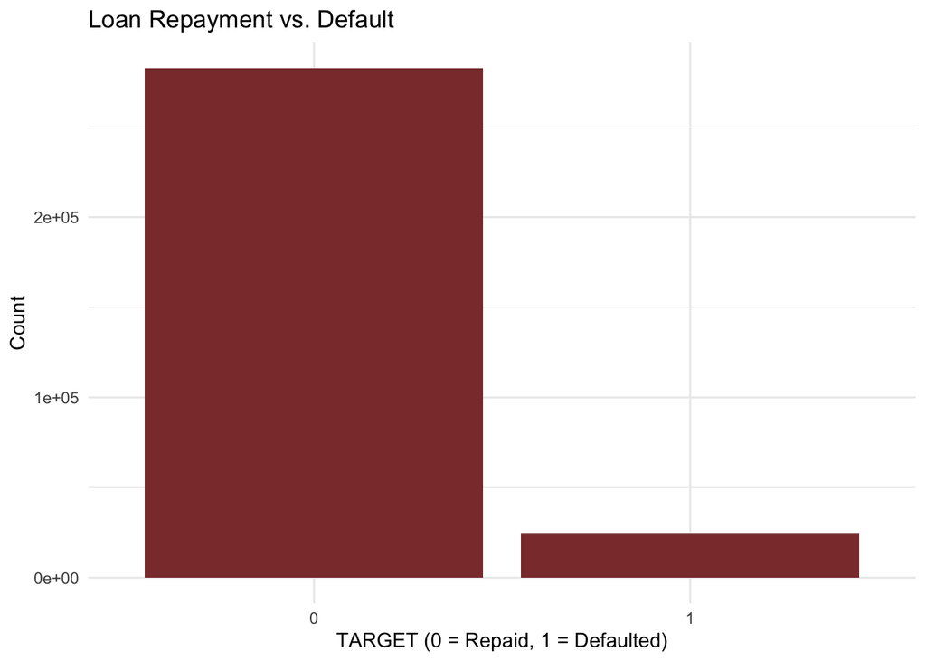

```r
ggplot(train, aes(x = as.factor(TARGET))) +
  geom_bar(fill = "indianred4") +
  labs(title = "Loan Repayment vs. Default", x = "TARGET (0 = Repaid, 1 = Defaulted)", y = "Count") +
  theme_minimal()
```

The dataset is imbalanced, with large repaid loans and small defaults. This means the model might focus too much on repaid loans and miss high-risk applicants. If not handled, it could lead to more loan defaults and financial losses. To fix this, techniques like oversampling or adjusting model training might applied.

# Discussion of Missing Data

## Check Misssing Value

```r
missing_values <- function(df) {
  missings <- colSums(is.na(df)) / nrow(df) * 100
  return(data.frame(Column = names(missings), Missing_Percentage = missings))
}

missing_summary <- list(
  train = missing_values(train),
  test = missing_values(test),
  bureau = missing_values(bureau),
  bureau_balance = missing_values(bureau_balance),
  previous_application = missing_values(previous_application),
  installments_payments = missing_values(installments_payments),
  credit_card_balance = missing_values(credit_card_balance)
)

# display
for (name in names(missing_summary)) {
  cat("\nMissing values in", name, ":\n")
  print(missing_summary[[name]] %>% filter(Missing_Percentage > 0) %>% arrange(desc(Missing_Percentage)))
}
```

```
##
## Missing values in train :
##                                                    Column Missing_Percentage
## COMMONAREA_AVG                             COMMONAREA_AVG       6.987230e+01
## COMMONAREA_MODE                           COMMONAREA_MODE       6.987230e+01
## COMMONAREA_MEDI                           COMMONAREA_MEDI       6.987230e+01
## NONLIVINGAPARTMENTS_AVG           NONLIVINGAPARTMENTS_AVG       6.943296e+01
## NONLIVINGAPARTMENTS_MODE         NONLIVINGAPARTMENTS_MODE       6.943296e+01
## NONLIVINGAPARTMENTS_MEDI         NONLIVINGAPARTMENTS_MEDI       6.943296e+01
## FONDKAPREMONT_MODE                     FONDKAPREMONT_MODE       6.838617e+01
## LIVINGAPARTMENTS_AVG                 LIVINGAPARTMENTS_AVG       6.835495e+01
## LIVINGAPARTMENTS_MODE               LIVINGAPARTMENTS_MODE       6.835495e+01
## LIVINGAPARTMENTS_MEDI               LIVINGAPARTMENTS_MEDI       6.835495e+01
## FLOORSMIN_AVG                               FLOORSMIN_AVG       6.784863e+01
## FLOORSMIN_MODE                             FLOORSMIN_MODE       6.784863e+01
## FLOORSMIN_MEDI                             FLOORSMIN_MEDI       6.784863e+01
## YEARS_BUILD_AVG                           YEARS_BUILD_AVG       6.649778e+01
## YEARS_BUILD_MODE                         YEARS_BUILD_MODE       6.649778e+01
## YEARS_BUILD_MEDI                         YEARS_BUILD_MEDI       6.649778e+01
## OWN_CAR_AGE                                   OWN_CAR_AGE       6.599081e+01
## LANDAREA_AVG                                 LANDAREA_AVG       5.937674e+01
## LANDAREA_MODE                               LANDAREA_MODE       5.937674e+01
## LANDAREA_MEDI                               LANDAREA_MEDI       5.937674e+01
## BASEMENTAREA_AVG                         BASEMENTAREA_AVG       5.851596e+01
## BASEMENTAREA_MODE                       BASEMENTAREA_MODE       5.851596e+01
## BASEMENTAREA_MEDI                       BASEMENTAREA_MEDI       5.851596e+01
## EXT_SOURCE_1                                 EXT_SOURCE_1       5.638107e+01
## NONLIVINGAREA_AVG                       NONLIVINGAREA_AVG       5.517916e+01
## NONLIVINGAREA_MODE                     NONLIVINGAREA_MODE       5.517916e+01
## NONLIVINGAREA_MEDI                     NONLIVINGAREA_MEDI       5.517916e+01
## ELEVATORS_AVG                               ELEVATORS_AVG       5.329598e+01
## ELEVATORS_MODE                             ELEVATORS_MODE       5.329598e+01
## ELEVATORS_MEDI                             ELEVATORS_MEDI       5.329598e+01
## WALLSMATERIAL_MODE                     WALLSMATERIAL_MODE       5.084078e+01
## APARTMENTS_AVG                             APARTMENTS_AVG       5.074973e+01
## APARTMENTS_MODE                           APARTMENTS_MODE       5.074973e+01
## APARTMENTS_MEDI                           APARTMENTS_MEDI       5.074973e+01
## ENTRANCES_AVG                               ENTRANCES_AVG       5.034877e+01
## ENTRANCES_MODE                             ENTRANCES_MODE       5.034877e+01
## ENTRANCES_MEDI                             ENTRANCES_MEDI       5.034877e+01
```

[output cut: 132 more lines]

```
##                                Column Missing_Percentage
## DAYS_ENTRY_PAYMENT DAYS_ENTRY_PAYMENT         0.02135181
## AMT_PAYMENT               AMT_PAYMENT         0.02135181
##
## Missing values in credit_card_balance :
##                                                Column Missing_Percentage
## AMT_PAYMENT_CURRENT               AMT_PAYMENT_CURRENT          19.998063
## AMT_DRAWINGS_ATM_CURRENT     AMT_DRAWINGS_ATM_CURRENT          19.524872
## AMT_DRAWINGS_OTHER_CURRENT AMT_DRAWINGS_OTHER_CURRENT          19.524872
## AMT_DRAWINGS_POS_CURRENT     AMT_DRAWINGS_POS_CURRENT          19.524872
## CNT_DRAWINGS_ATM_CURRENT     CNT_DRAWINGS_ATM_CURRENT          19.524872
## CNT_DRAWINGS_OTHER_CURRENT CNT_DRAWINGS_OTHER_CURRENT          19.524872
## CNT_DRAWINGS_POS_CURRENT     CNT_DRAWINGS_POS_CURRENT          19.524872
## AMT_INST_MIN_REGULARITY       AMT_INST_MIN_REGULARITY           7.948208
## CNT_INSTALMENT_MATURE_CUM   CNT_INSTALMENT_MATURE_CUM           7.948208
```

## Remove Columns with Too Many Missing Values

```r
# Function to remove columns with high missing percentage
remove_high_missing <- function(df, threshold = 50) {
  missing_perc <- colSums(is.na(df)) / nrow(df) * 100
  cols_to_keep <- names(missing_perc[missing_perc < threshold])
  return(df[, cols_to_keep])
}


train <- remove_high_missing(train)
test <- remove_high_missing(test)
bureau <- remove_high_missing(bureau)
previous_application <- remove_high_missing(previous_application)
credit_card_balance <- remove_high_missing(credit_card_balance)
POS_CASH_balance <- remove_high_missing(POS_CASH_balance)
installments_payments <- remove_high_missing(installments_payments)
```

## Fill Numeric Columns with Mean/Median

```r
# Function to fill missing values with median
fill_missing_numeric <- function(df) {
  for (col in colnames(df)) {
    if (is.numeric(df[[col]])) {
      df[[col]][is.na(df[[col]])] <- median(df[[col]], na.rm = TRUE)
    }
  }
  return(df)
}

train <- fill_missing_numeric(train)
test <- fill_missing_numeric(test)
bureau <- fill_missing_numeric(bureau)
previous_application <- fill_missing_numeric(previous_application)
credit_card_balance <- fill_missing_numeric(credit_card_balance)
POS_CASH_balance <- fill_missing_numeric(POS_CASH_balance)
installments_payments <- fill_missing_numeric(installments_payments)
```

## Fill Categorical Columns with Most Frequent Value

```r
# Function to fill missing categorical values with the most frequent category
fill_missing_categorical <- function(df) {
  for (col in colnames(df)) {
    if (is.character(df[[col]])) {
      most_frequent <- names(sort(table(df[[col]]), decreasing = TRUE))[1]
      df[[col]][is.na(df[[col]])] <- most_frequent
    }
  }
  return(df)
}


train <- fill_missing_categorical(train)
test <- fill_missing_categorical(test)
previous_application <- fill_missing_categorical(previous_application)
```

## No Missing Values Left

```r
check_missing <- function(df, name) {
  missing_count <- sum(is.na(df))
  cat(name, "- Remaining Missing Values:", missing_count, "\n")
}

check_missing(train, "train")
```

```
## train - Remaining Missing Values: 0
```

```r
check_missing(test, "test")
```

```
## test - Remaining Missing Values: 0
```

```r
check_missing(bureau, "bureau")
```

```
## bureau - Remaining Missing Values: 0
```

```r
check_missing(previous_application, "previous_application")
```

```
## previous_application - Remaining Missing Values: 0
```

```r
check_missing(credit_card_balance, "credit_card_balance")
```

```
## credit_card_balance - Remaining Missing Values: 0
```

```r
check_missing(POS_CASH_balance, "POS_CASH_balance")
```

```
## POS_CASH_balance - Remaining Missing Values: 0
```

```r
check_missing(installments_payments, "installments_payments")
```

```
## installments_payments - Remaining Missing Values: 0
```

# Data Coverting

## Convert variables to factors

```r
# Convert character variables to factors before merging (to save memory)
train <- train %>% mutate_if(is.character, as.factor)
test <- test %>% mutate_if(is.character, as.factor)
bureau <- bureau %>% mutate_if(is.character, as.factor)
bureau_balance <- bureau_balance %>% mutate_if(is.character, as.factor)
previous_application <- previous_application %>% mutate_if(is.character, as.factor)
POS_CASH_balance <- POS_CASH_balance %>% mutate_if(is.character, as.factor)
installments_payments <- installments_payments %>% mutate_if(is.character, as.factor)
credit_card_balance <- credit_card_balance %>% mutate_if(is.character, as.factor)
```

# Exploratory Visualizations and Summary Tables

## Visualize Differences in Income & Loan Amount

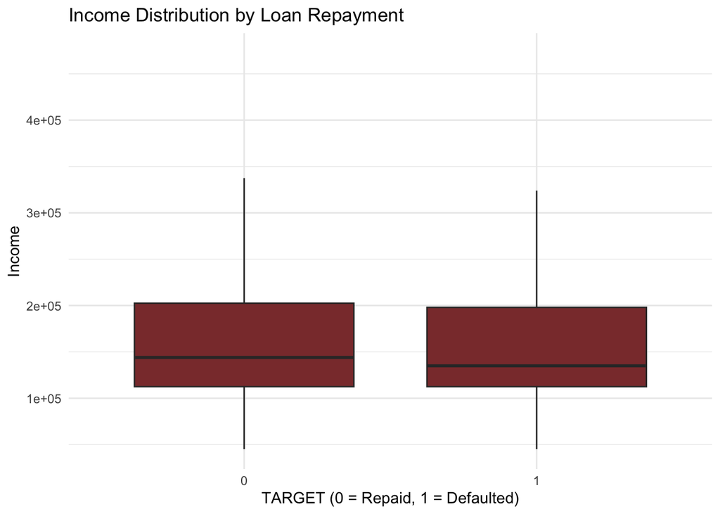

```r
ggplot(train, aes(x = as.factor(TARGET), y = AMT_INCOME_TOTAL)) +
  geom_boxplot(fill = "indianred4", outlier.shape = NA) +
  scale_y_continuous(limits = quantile(train$AMT_INCOME_TOTAL, c(0.01, 0.99), na.rm = TRUE)) +
  labs(title = "Income Distribution by Loan Repayment", x = "TARGET (0 = Repaid, 1 = Defaulted)", y = "Income") +
  theme_minimal()
```

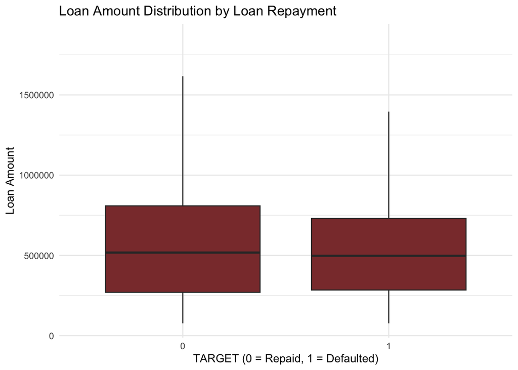

```r
ggplot(train, aes(x = as.factor(TARGET), y = AMT_CREDIT)) +
  geom_boxplot(fill = "indianred4", outlier.shape = NA) +
  scale_y_continuous(limits = quantile(train$AMT_CREDIT, c(0.01, 0.99), na.rm = TRUE)) +
  labs(title = "Loan Amount Distribution by Loan Repayment", x = "TARGET (0 = Repaid, 1 = Defaulted)", y = "Loan Amount") +
  theme_minimal()
```

## Financial Behavior Analysis

- **Check how many applicants had previous loans from other financial institutions.**
- **Calculate the average number of past credits per applicant.**

```r
# Count applicants with previous loans
applicants_with_external_loans <- bureau %>%
  group_by(SK_ID_CURR) %>%
  summarise(num_past_loans = n()) %>%
  filter(num_past_loans > 0)

# Number of applicants with external loans
num_applicants_with_loans <- n_distinct(applicants_with_external_loans$SK_ID_CURR)
cat("Number of applicants with previous external loans:", num_applicants_with_loans, "\n")
```

```
## Number of applicants with previous external loans: 305811
```

```r
# Average number of past credits per applicant
avg_past_credits <- mean(applicants_with_external_loans$num_past_loans)
cat("Average number of past credits per applicant:", avg_past_credits, "\n")
```

```
## Average number of past credits per applicant: 5.612709
```

## Analyzing Payment Behavior

```r
# Late or missed payments in credit card balance
late_credit_payments <- credit_card_balance %>%
  filter(AMT_PAYMENT_CURRENT < AMT_INST_MIN_REGULARITY) %>%
  group_by(SK_ID_CURR) %>%
  summarise(num_late_payments = n())

# Late or missed payments in installments
late_installments <- installments_payments %>%
  filter(DAYS_ENTRY_PAYMENT > DAYS_INSTALMENT) %>%
  group_by(SK_ID_CURR) %>%
  summarise(num_late_installments = n())

# POS_CASH_balance - Count overdue payments
overdue_POS <- POS_CASH_balance %>%
  filter(SK_DPD > 0) %>%
  group_by(SK_ID_CURR) %>%
  summarise(num_overdue_POS = n())

# Avg missed payments per applicant
avg_late_credit <- mean(late_credit_payments$num_late_payments, na.rm = TRUE)
avg_late_installments <- mean(late_installments$num_late_installments, na.rm = TRUE)
avg_overdue_POS <- mean(overdue_POS$num_overdue_POS, na.rm = TRUE)

cat("Average number of late credit card payments:", avg_late_credit, "\n")
```

```
## Average number of late credit card payments: 3.057132
```

```r
cat("Average number of late installment payments:", avg_late_installments, "\n")
```

```
## Average number of late installment payments: 6.380752
```

```r
cat("Average number of overdue POS payments:", avg_overdue_POS, "\n")
```

```
## Average number of overdue POS payments: 4.687333
```

# Feature Engineering: Aggregating Financial Data

```r
# Aggregate secondary datasets to ensure one row per SK_ID_CURR
bureau_agg <- bureau %>%
  group_by(SK_ID_CURR) %>%
  summarise(TOTAL_CREDIT_ACTIVE = n(),
            MAX_CREDIT_OVERDUE = max(CREDIT_DAY_OVERDUE, na.rm=TRUE))

previous_application_agg <- previous_application %>%
  group_by(SK_ID_CURR) %>%
  summarise(TOTAL_PREVIOUS_APPLICATIONS = n(),
            AVERAGE_AMT_CREDIT = mean(AMT_CREDIT, na.rm=TRUE))

POS_CASH_balance_agg <- POS_CASH_balance %>%
  group_by(SK_ID_CURR) %>%
  summarise(AVERAGE_MONTHS_BALANCE = mean(MONTHS_BALANCE, na.rm=TRUE))

credit_card_balance_agg <- credit_card_balance %>%
  group_by(SK_ID_CURR) %>%
  summarise(AVERAGE_AMT_BALANCE = mean(AMT_BALANCE, na.rm=TRUE))

installments_payments_agg <- installments_payments %>%
  group_by(SK_ID_CURR) %>%
  summarise(AVERAGE_DAYS_INSTALMENT = mean(DAYS_INSTALMENT, na.rm=TRUE))
```

## Merge into Main Train Data

```r
# Merge datasets
merged_train <- train %>%
  left_join(bureau_agg, by = "SK_ID_CURR") %>%
  left_join(previous_application_agg, by = "SK_ID_CURR") %>%
  left_join(POS_CASH_balance_agg, by = "SK_ID_CURR") %>%
  left_join(credit_card_balance_agg, by = "SK_ID_CURR") %>%
  left_join(installments_payments_agg, by = "SK_ID_CURR")
```

## Merge into Main Test Data

```r
# Merge test dataset separately for prediction
merged_test <- test %>%
  left_join(bureau_agg, by = "SK_ID_CURR") %>%
  left_join(previous_application_agg, by = "SK_ID_CURR") %>%
  left_join(POS_CASH_balance_agg, by = "SK_ID_CURR") %>%
  left_join(credit_card_balance_agg, by = "SK_ID_CURR") %>%
  left_join(installments_payments_agg, by = "SK_ID_CURR")
```

## Display Merged

```r
# Display dataset
cat("Train Data: ", dim(merged_train), "\n")
```

```
## Train Data:  307511 88
```

```r
cat("Test Data: ", dim(merged_test), "\n")
```

```
## Test Data:  48744 99
```

# Final Data Wrangling

## Check Missing Values in Final Merged Datasets

```r
# Function to check missing values in a dataset
check_missing <- function(df, name) {
  missing_count <- sum(is.na(df))
  missing_percentage <- (missing_count / (nrow(df) * ncol(df))) * 100
  cat(name, "- Total Missing Values:", missing_count,
      "| Percentage of Missing Values:", round(missing_percentage, 2), "%\n")
}

# Check missing values in merged train and test datasets
check_missing(merged_train, "Merged Train Data")
```

```
## Merged Train Data - Total Missing Values: 375489 | Percentage of Missing Values: 1.39 %
```

```r
check_missing(merged_test, "Merged Test Data")
```

```
## Merged Test Data - Total Missing Values: 48563 | Percentage of Missing Values: 1.01 %
```

```r
# Show columns with missing values in merged_train
missing_train_summary <- colSums(is.na(merged_train)) / nrow(merged_train) * 100
missing_train_summary <- missing_train_summary[missing_train_summary > 0]
if (length(missing_train_summary) > 0) {
  cat("\nColumns with Missing Values in Merged Train Data:\n")
  print(missing_train_summary)
}
```

```
##
## Columns with Missing Values in Merged Train Data:
##         TOTAL_CREDIT_ACTIVE          MAX_CREDIT_OVERDUE
##                   14.314935                   14.314935
## TOTAL_PREVIOUS_APPLICATIONS          AVERAGE_AMT_CREDIT
##                    5.350703                    5.350703
##      AVERAGE_MONTHS_BALANCE         AVERAGE_AMT_BALANCE
##                    5.875237                   71.739222
##     AVERAGE_DAYS_INSTALMENT
##                    5.160141
```

```r
# Show columns with missing values in merged_test
missing_test_summary <- colSums(is.na(merged_test)) / nrow(merged_test) * 100
missing_test_summary <- missing_test_summary[missing_test_summary > 0]
if (length(missing_test_summary) > 0) {
  cat("\nColumns with Missing Values in Merged Test Data:\n")
  print(missing_test_summary)
}
```

```
##
## Columns with Missing Values in Merged Test Data:
##         TOTAL_CREDIT_ACTIVE          MAX_CREDIT_OVERDUE
##                   13.179058                   13.179058
## TOTAL_PREVIOUS_APPLICATIONS          AVERAGE_AMT_CREDIT
##                    1.936649                    1.936649
##      AVERAGE_MONTHS_BALANCE         AVERAGE_AMT_BALANCE
##                    1.920236                   65.835795
##     AVERAGE_DAYS_INSTALMENT
##                    1.641228
```

## Replace Nas By Zero

```r
# Function to fill missing values in merged datasets
fill_missing_values <- function(df) {
  df$TOTAL_CREDIT_ACTIVE[is.na(df$TOTAL_CREDIT_ACTIVE)] <- 0
  df$MAX_CREDIT_OVERDUE[is.na(df$MAX_CREDIT_OVERDUE)] <- 0
  df$TOTAL_PREVIOUS_APPLICATIONS[is.na(df$TOTAL_PREVIOUS_APPLICATIONS)] <- 0
  df$AVERAGE_AMT_CREDIT[is.na(df$AVERAGE_AMT_CREDIT)] <- 0
  df$AVERAGE_MONTHS_BALANCE[is.na(df$AVERAGE_MONTHS_BALANCE)] <- 0
  df$AVERAGE_AMT_BALANCE[is.na(df$AVERAGE_AMT_BALANCE)] <- 0
  df$AVERAGE_DAYS_INSTALMENT[is.na(df$AVERAGE_DAYS_INSTALMENT)] <- 0
  return(df)
}

# Apply missing value handling to both datasets
merged_train <- fill_missing_values(merged_train)
merged_test <- fill_missing_values(merged_test)
```

## Verify no missing values remain

```r
check_missing(merged_train, "Merged Train Data (After Fixing)")
```

```
## Merged Train Data (After Fixing) - Total Missing Values: 0 | Percentage of Missing Values: 0 %
```

```r
check_missing(merged_test, "Merged Test Data (After Fixing)")
```

```
## Merged Test Data (After Fixing) - Total Missing Values: 0 | Percentage of Missing Values: 0 %
```

# Correlation Analysis

## Correlation Table

```r
merged_train$TARGET <- as.factor(merged_train$TARGET)

numeric_columns <- merged_train %>%
  select(where(is.numeric))

# Compute Point Biserial Correlation for each numeric variable with TARGET
cor_results <- sapply(numeric_columns, function(x) {
  cor.test(x, as.numeric(merged_train$TARGET), method = "pearson")$estimate
})

# Sort correlations by absolute value
cor_results_sorted <- sort(abs(cor_results), decreasing = TRUE)

# Display results
print(cor_results_sorted)
```

```
##                 EXT_SOURCE_2.cor                 EXT_SOURCE_3.cor
##                     1.602948e-01                     1.558917e-01
##                   DAYS_BIRTH.cor  REGION_RATING_CLIENT_W_CITY.cor
##                     7.823931e-02                     6.089267e-02
##         REGION_RATING_CLIENT.cor       DAYS_LAST_PHONE_CHANGE.cor
##                     5.889901e-02                     5.521823e-02
##              DAYS_ID_PUBLISH.cor       REG_CITY_NOT_WORK_CITY.cor
##                     5.145717e-02                     5.099446e-02
##          AVERAGE_AMT_BALANCE.cor               FLAG_EMP_PHONE.cor
##                     4.852282e-02                     4.598222e-02
##                DAYS_EMPLOYED.cor       REG_CITY_NOT_LIVE_CITY.cor
##                     4.493166e-02                     4.439537e-02
##              FLAG_DOCUMENT_3.cor            DAYS_REGISTRATION.cor
##                     4.434635e-02                     4.197486e-02
##              AMT_GOODS_PRICE.cor                FLOORSMAX_AVG.cor
##                     3.962326e-02                     3.938546e-02
##               FLOORSMAX_MEDI.cor               FLOORSMAX_MODE.cor
##                     3.915721e-02                     3.837709e-02
##   REGION_POPULATION_RELATIVE.cor      AVERAGE_DAYS_INSTALMENT.cor
##                     3.722715e-02                     3.446098e-02
##      LIVE_CITY_NOT_WORK_CITY.cor     DEF_30_CNT_SOCIAL_CIRCLE.cor
##                     3.251834e-02                     3.239422e-02
##     DEF_60_CNT_SOCIAL_CIRCLE.cor                   AMT_CREDIT.cor
##                     3.140053e-02                     3.036929e-02
##               TOTALAREA_MODE.cor              FLAG_DOCUMENT_6.cor
##                     3.021397e-02                     2.860189e-02
##              FLAG_WORK_PHONE.cor       AVERAGE_MONTHS_BALANCE.cor
##                     2.852432e-02                     2.681287e-02
##      HOUR_APPR_PROCESS_START.cor                   FLAG_PHONE.cor
##                     2.416583e-02                     2.380627e-02
##  TOTAL_PREVIOUS_APPLICATIONS.cor                 CNT_CHILDREN.cor
##                     2.351339e-02                     1.918713e-02
##    AMT_REQ_CREDIT_BUREAU_MON.cor                  AMT_ANNUITY.cor
##                     1.479372e-02                     1.281477e-02
##   AMT_REQ_CREDIT_BUREAU_YEAR.cor             FLAG_DOCUMENT_16.cor
##                     1.216123e-02                     1.161467e-02
##             FLAG_DOCUMENT_13.cor           AVERAGE_AMT_CREDIT.cor
##                     1.158322e-02                     1.108958e-02
##          TOTAL_CREDIT_ACTIVE.cor             FLAG_DOCUMENT_14.cor
##                     1.001972e-02                     9.463822e-03
```

[output cut: 19 more lines]

```
##                     3.377569e-03                     2.819479e-03
##              FLAG_DOCUMENT_4.cor                   SK_ID_CURR.cor
##                     2.672082e-03                     2.108469e-03
##                   FLAG_EMAIL.cor    AMT_REQ_CREDIT_BUREAU_DAY.cor
##                     1.758383e-03                     1.701074e-03
##              FLAG_DOCUMENT_7.cor             FLAG_DOCUMENT_10.cor
##                     1.519503e-03                     1.413892e-03
##             FLAG_DOCUMENT_19.cor   AMT_REQ_CREDIT_BUREAU_WEEK.cor
##                     1.357518e-03                     1.305670e-03
##             FLAG_DOCUMENT_12.cor                   FLAG_MOBIL.cor
##                     7.557507e-04                     5.343956e-04
##             FLAG_CONT_MOBILE.cor              FLAG_DOCUMENT_5.cor
##                     3.701268e-04                     3.157774e-04
##             FLAG_DOCUMENT_20.cor   AMT_REQ_CREDIT_BUREAU_HOUR.cor
##                     2.153936e-04                     7.362712e-05
```

## Top 10 Correlation Variables

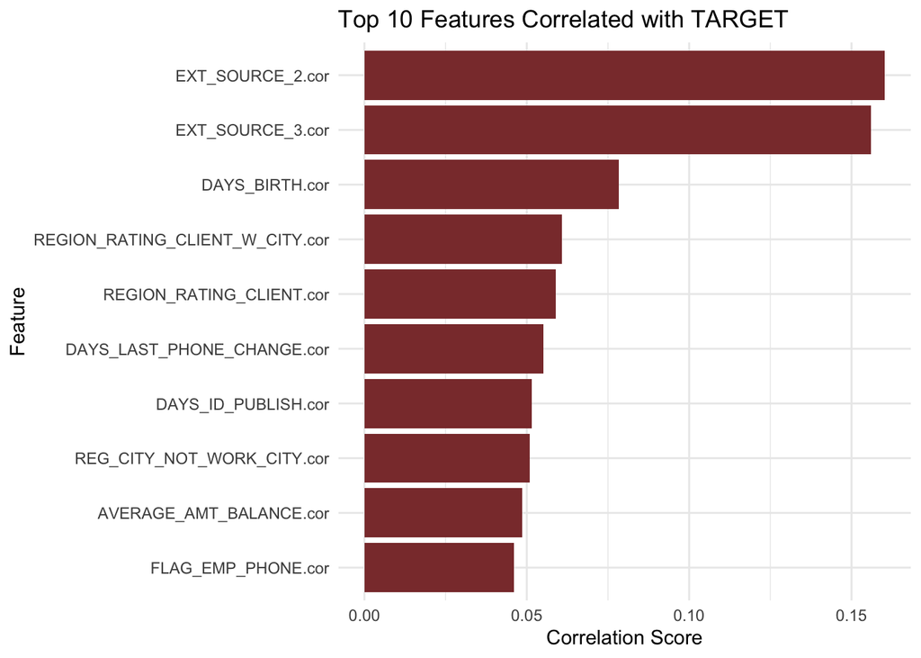

```r
# Convert correlation results to data frame
cor_df <- data.frame(Feature = names(cor_results_sorted), Correlation = cor_results_sorted)

# Select top 10 correlated features (adjust if less than 10 exist)
top_features <- cor_df[1:min(10, nrow(cor_df)), ]


ggplot(top_features, aes(x = reorder(Feature, Correlation), y = Correlation)) +
  geom_bar(stat = "identity", fill = "indianred4") +
  coord_flip() +
  labs(title = "Top 10 Features Correlated with TARGET", x = "Feature", y = "Correlation Score") +
  theme_minimal()
```

# Results Section

The analysis found a significant class imbalance in the dataset, with 91.9% of applicants repaying loans and only 8.1% defaulting. This imbalance may affect model performance and requires techniques to ensure fair predictions.

# Export Finial Merged Data for Models

```r
# Save merged datasets for modeling
write.csv(merged_train, "merged_train.csv", row.names = FALSE)
write.csv(merged_test, "merged_test.csv", row.names = FALSE)
```